# Coursera Data Science Capstone: Exploratory Data Analysis

Venkatesh Attinti

5/26/2020

## Executive Summary

This milestone report is based on the exploratory data analysis of the swift key data provided in context of Data science capstone project.The data consist of 3 data file from different sources - (twitter,blogs,news).This report showcases the tidytext approach used for data analysis.More information regarding the tidy text approach can be accessed from here https://www.tidytextmining.com/

## Data Summary

It is assumed that the data from https://d396qusza40orc.cloudfront.net/dsscapstone/dataset/Coursera-SwiftKey.zip is downloaded, unziped and available in the working directory.

### Below is the summary of the data loaded

```r
library("stringi")

twitterRawData <- readLines("en_US.twitter.txt",warn=FALSE,encoding="UTF-8")
blogsRawData <- readLines("en_US.blogs.txt",warn=FALSE,encoding="UTF-8")
newsRawData <- readLines("en_US.news.txt",warn=FALSE,encoding="UTF-8")

datasummary <- data.frame("FileNames" =c("Twitter","Blogs","News"),
                          "FileSize"=c(format(object.size(twitterRawData), units = "MB", standard ="auto"),
                                       format(object.size(blogsRawData), units = "MB", standard = "auto"),
                                       format(object.size(newsRawData), units = "MB", standard = "auto")),
                          "FileLength"=c(length(twitterRawData),length(blogsRawData),length(newsRawData)),
                          "Wordcount"=c(sum(stri_stats_latex(twitterRawData)[4]),sum(stri_stats_latex(blogsRawData)[4]),sum(stri_stats_latex(newsRawData)[4])),
                          "NoOfChars"=c(sum(nchar(twitterRawData)),sum(nchar(blogsRawData)),sum(nchar(newsRawData))))

datasummary
```

```
##   FileNames FileSize FileLength Wordcount NoOfChars
## 1   Twitter   319 Mb    2360148  30451128 162096031
## 2     Blogs 255.4 Mb     899288  37570839 206824505
## 3      News  19.8 Mb      77259   2651432  15639408
```

## Exploratory Data Analysis

In this section we will perform some exploratory data analysis using tidy data principles which is a powerful way to make handling data easier and more effective.

we will perform this analysis on the sample data set which is 2% of the original dataset.

Below are packages requried to perform this analysis library(“tidyr”) library(“dplyr”) library(“tidytext”) library(“tm”) library(“openNLP”) library(“RWeka”) library(“tm”)

```r
# Remove all non english characters as they cause issues down the road
twitterRawData <- iconv(twitterRawData, "latin1", "ASCII", sub="")
blogsRawData <- iconv(blogsRawData, "latin1", "ASCII", sub="")
newsRawData <- iconv(newsRawData, "latin1", "ASCII", sub="")

#sampling of the data set
set.seed(2020)
twitterRawData_sample<- sample(twitterRawData,length(twitterRawData)*0.02)
blogsRawData_sample<- sample(blogsRawData,length(blogsRawData)*0.02)
newsRawData_sample<- sample(newsRawData,length(newsRawData)*0.02)

#write the sample files

dir.create("sampleDatafiles", showWarnings = FALSE)

write(twitterRawData_sample, "sampleDatafiles/twitterRawData_sample.txt")
write(blogsRawData_sample, "sampleDatafiles/blogsRawData_sample.txt")
write(newsRawData_sample, "sampleDatafiles/newsRawData_sample.txt")


remove(twitterRawData)
remove(blogsRawData)
remove(newsRawData)
```

Merging the sample data files into single corpus and then converting to tibble data frame format which will be used in all the further analysis

```r
library("tidyr")
library("dplyr")
library("tidytext")
library("tm")
library("openNLP")
library("RWeka")
library("tm")
finalSampleData <- c(twitterRawData_sample,blogsRawData_sample,newsRawData_sample)
sampleData <- tibble(text = finalSampleData)
```

Pre-processing the data(invloves operations like removing the whitespaces, punctuation,stopwords, stemming etc) In tidy text the punctuations and converting to lower cases are automatically done during the unnesting tokens.

## Unigrams

Unnesting tokens and removing the stopwords

```r
data(stop_words)
tidySampleData <- sampleData %>% unnest_tokens(word, text) %>% anti_join(stop_words)
#Removing whitespaces
tidySampleData$word <- gsub("\\s+","",tidySampleData$word)
#Removing Numbers
tidySampleData<-tidySampleData[-grep("\\b\\d+\\b", tidySampleData$word),]

tidySampleData %>% count(word, sort = TRUE);
```

```
## # A tibble: 61,207 x 2
##    word       n
##    <chr>  <int>
##  1 time    3486
##  2 love    3091
##  3 day     2960
##  4 people  2253
##  5 rt      1780
##  6 life    1542
##  7 lol     1459
##  8 happy   1286
##  9 im      1220
## 10 night   1167
## # ... with 61,197 more rows
```

using tidy tools,the word counts are stored in a tidy data frame.This allows us to pipe directly to the ggplot2 package

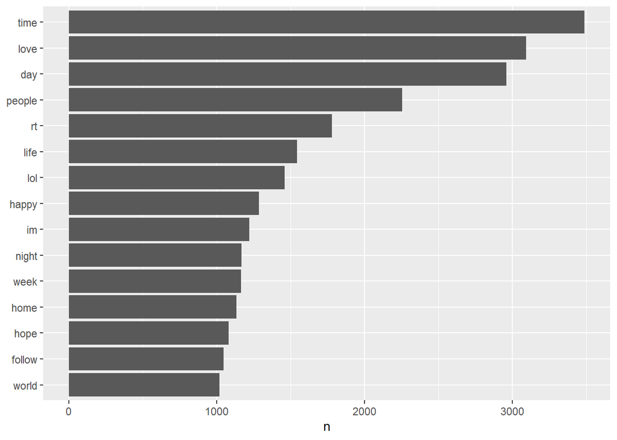

```r
library(ggplot2)
tidySampleData %>% count(word, sort = TRUE) %>% filter(n > 1000) %>% mutate(word = reorder(word, n)) %>% ggplot(aes(word, n)) + geom_col() + xlab(NULL) + coord_flip();
```

Displaying the most common unnigrams using wordcloud

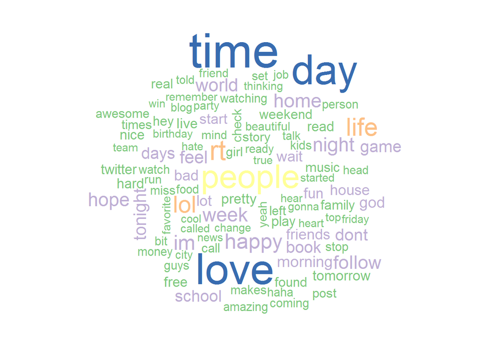

```r
library(wordcloud)
library("RColorBrewer")
dark2 <- brewer.pal(5, "Accent")

tidySampleData %>% count(word) %>% with(wordcloud(word, n, max.words = 100, rot.per=0.1, colors=dark2));
```

### Bigrams – Tokenizing by 2-gram

```r
library(tidyr)
stop_words <- rbind(stop_words,data.frame(word="amp",lexicon=""))
tidyBigramSampleData <- sampleData %>% unnest_tokens(bigram, text,token = "ngrams", n = 2)
#Seperating the bigram
tidyBigramSampleData_separated <- tidyBigramSampleData %>% separate(bigram, c("word1", "word2"), sep = " ")
bigrams_filtered <- tidyBigramSampleData_separated %>% filter(!word1 %in% stop_words$word) %>% filter(!word2 %in% stop_words$word)
#Removing whitespaces
bigrams_filtered$word1 <- gsub("\\s+","",bigrams_filtered$word1)
bigrams_filtered$word2 <- gsub("\\s+","",bigrams_filtered$word2)

bigrams_filtered$word1 <- gsub("\\'+","",bigrams_filtered$word1)
bigrams_filtered$word2 <- gsub("\\'+","",bigrams_filtered$word2)

#Removing Numbers
bigrams_filtered<-bigrams_filtered[-grep("\\b\\d+\\b", bigrams_filtered$word1),]
bigrams_filtered<-bigrams_filtered[-grep("\\b\\d+\\b", bigrams_filtered$word2),]

bigrams_united <- bigrams_filtered %>% unite(bigram, word1, word2, sep = " ")
bigrams_united %>% count(bigram,sort=TRUE)
```

```
## # A tibble: 173,641 x 2
##    bigram             n
##    <chr>          <int>
##  1 happy birthday   171
##  2 mothers day      128
##  3 social media      99
##  4 ice cream         62
##  5 stay tuned        62
##  6 happy mothers     60
##  7 rt rt             59
##  8 los angeles       53
##  9 san diego         49
## 10 happy friday      48
## # ... with 173,631 more rows
```

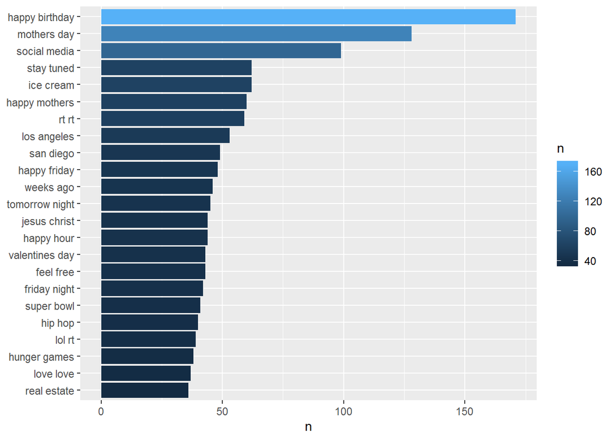

```r
bigrams_united %>% count(bigram, sort = TRUE) %>% filter(n > 35) %>% mutate(bigram = reorder(bigram, n)) %>% ggplot(aes(bigram, n,fill=n)) + geom_col() + xlab(NULL) + coord_flip()
```

### Visualizing a Network of Bigrams with ggraph

It may be interested in visualizing all of the relationships among words simultaneously,rather than just the top few at a time. As one common visualization, we can arrange the words into a network, or “graph.”

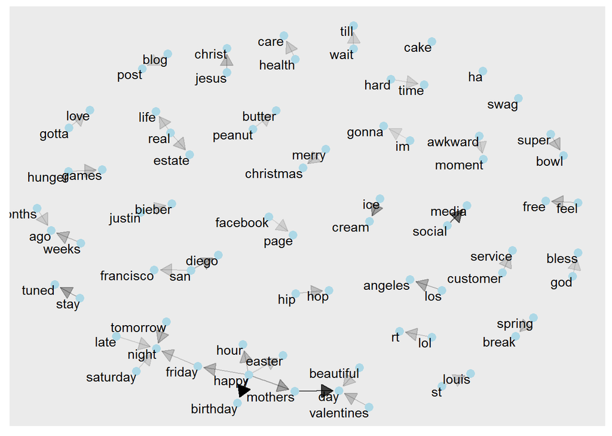

```r
library(igraph)
bigram_graph <- bigrams_filtered %>% count(word1, word2,sort=TRUE) %>% filter(n > 25) %>% graph_from_data_frame()
library(ggraph)
set.seed(123456)
a <- grid::arrow(type = "closed", length = unit(.15, "inches"))
ggraph(bigram_graph, layout = "fr") +
geom_edge_link(aes(edge_alpha = n), show.legend = FALSE,
arrow = a, end_cap = circle(.07, 'inches')) +
geom_node_point(color = "lightblue",size=3) +
geom_node_text(aes(label = name), vjust = 1, hjust = 1)
```

### Trigrams – Tokenizing by 3-gram

```r
library(tidyr)
stop_words <- rbind(stop_words,data.frame(word="amp",lexicon=""))
tidyBigramSampleData <- sampleData %>% unnest_tokens(bigram, text,token = "ngrams", n = 3)
#Seperating the bigram
tidyBigramSampleData_separated <- tidyBigramSampleData %>% separate(bigram, c("word1", "word2", "word3"), sep = " ")
bigrams_filtered <- tidyBigramSampleData_separated %>% filter(!word1 %in% stop_words$word) %>% filter(!word2 %in% stop_words$word)%>% filter(!word3 %in% stop_words$word)
#Removing whitespaces
bigrams_filtered$word1 <- gsub("\\s+","",bigrams_filtered$word1)
bigrams_filtered$word2 <- gsub("\\s+","",bigrams_filtered$word2)
bigrams_filtered$word3 <- gsub("\\s+","",bigrams_filtered$word3)

bigrams_filtered$word1 <- gsub("\\'+","",bigrams_filtered$word1)
bigrams_filtered$word2 <- gsub("\\'+","",bigrams_filtered$word2)
bigrams_filtered$word3 <- gsub("\\'+","",bigrams_filtered$word3)

#Removing Numbers
bigrams_filtered<-bigrams_filtered[-grep("\\b\\d+\\b", bigrams_filtered$word1),]
bigrams_filtered<-bigrams_filtered[-grep("\\b\\d+\\b", bigrams_filtered$word2),]
bigrams_filtered<-bigrams_filtered[-grep("\\b\\d+\\b", bigrams_filtered$word3),]

bigrams_united <- bigrams_filtered %>% unite(bigram, word1, word2,word3, sep = " ")
bigrams_united %>% count(bigram,sort=TRUE)
```

```
## # A tibble: 76,501 x 2
##    bigram                      n
##    <chr>                   <int>
##  1 happy mothers day          60
##  2 cake cake cake             25
##  3 swag swag swag             25
##  4 cinco de mayo              20
##  5 custom paintball jersey    19
##  6 design custom paintball    19
##  7 love love love             16
##  8 ugly ugly ugly             16
##  9 happy valentines day       12
## 10 mikey mikey mikey          12
## # ... with 76,491 more rows
```

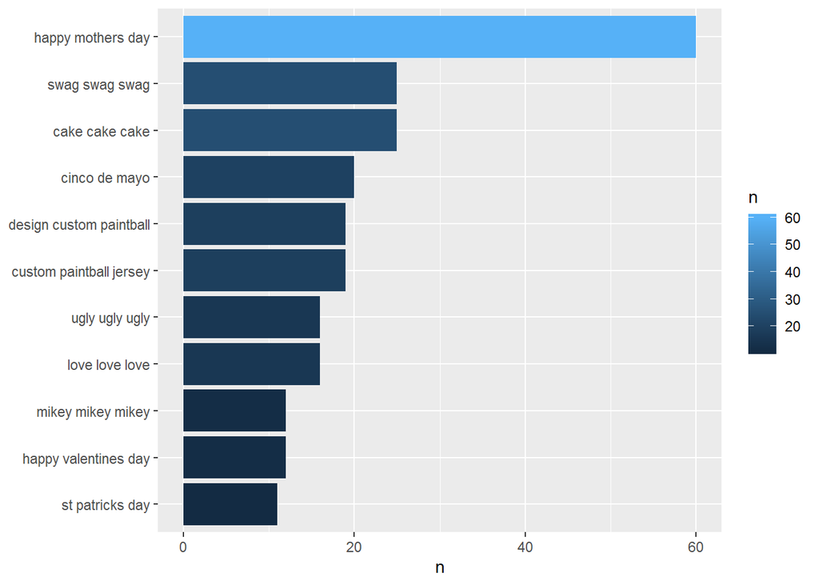

```r
bigrams_united %>% count(bigram, sort = TRUE) %>% filter(n > 10) %>% mutate(bigram = reorder(bigram, n)) %>% ggplot(aes(bigram, n,fill=n)) + geom_col() + xlab(NULL) + coord_flip()
```

### Plan of next steps

I have done the exploratory analysis. The next steps of this capstone project would be to finalize our predictive algorithm, and deploy our algorithm using shiny() app. As for the Shiny app it will consist of a simple user interface that will allow a user to enter text into a single textbox.